# ufosightings

WHAT'S UP (there)?

This tutorial for CMSC320 will be exploring a dataset of over 80,000 UFO sightings over the past century. I will be using the scrubbed dataset provided on Kaggle. You can find it with the following link: https://www.kaggle.com/NUFORC/ufo-sightings?select=scrubbed.csv.

The overall motivation behind this tutorial is to find trends in UFO sightings. Are certain areas of the country "hotspots"? How long do sightings normally last? What kinds of 'shapes' do people see when they do report a sighting? Have there been any significant clusters of sightings in the past that indicate something unknown really may have been out there? All questions we can try and answer...

Eva Utzschneider

```python
!pip install folium
import pandas as pd
import numpy
import matplotlib.pyplot as plt
import folium
from folium import plugins
import warnings

warnings.filterwarnings('ignore');

pd.options.mode.chained_assignment = None  # default='warn'

# Reading a CSV file with Pandas. Doing so makes it easy to quickly access your table as you work on exploration and see
# data neatly organized. We can also use pandas for its other methods, as you will see below.

df = pd.read_csv('scrubbed.csv', low_memory = False)
df.head()
```

|  | datetime | city | state | country | shape | duration (seconds) | duration (hours/min) | comments | date posted | latitude | longitude |
| --- | --- | --- | --- | --- | --- | --- | --- | --- | --- | --- | --- |
| 0 | 10/10/1949 20:30 | san marcos | tx | us | cylinder | 2700 | 45 minutes | This event took place in early fall around 194... | 4/27/2004 | 29.8830556 | -97.941111 |
| 1 | 10/10/1949 21:00 | lackland afb | tx | NaN | light | 7200 | 1-2 hrs | 1949 Lackland AFB&#44 TX. Lights racing acros... | 12/16/2005 | 29.38421 | -98.581082 |
| 2 | 10/10/1955 17:00 | chester (uk/england) | NaN | gb | circle | 20 | 20 seconds | Green/Orange circular disc over Chester&#44 En... | 1/21/2008 | 53.2 | -2.916667 |
| 3 | 10/10/1956 21:00 | edna | tx | us | circle | 20 | 1/2 hour | My older brother and twin sister were leaving ... | 1/17/2004 | 28.9783333 | -96.645833 |
| 4 | 10/10/1960 20:00 | kaneohe | hi | us | light | 900 | 15 minutes | AS a Marine 1st Lt. flying an FJ4B fighter/att... | 1/22/2004 | 21.4180556 | -157.803611 |

```python
# DATA COLLECTION AND PARSING

# Understanding what we're looking at:
df.info()

# Based on this information we can see there are a total of 80,332 UFO sighting entries. However, it also shows that some columns
# have far less non-null entries, like state and country. To start shaving this dataset down, we're going to focus on sightings made
# in the United States.
```

```
<class 'pandas.core.frame.DataFrame'>
RangeIndex: 80332 entries, 0 to 80331
Data columns (total 11 columns):
 #   Column                Non-Null Count  Dtype
---  ------                --------------  -----
 0   datetime              80332 non-null  object
 1   city                  80332 non-null  object
 2   state                 74535 non-null  object
 3   country               70662 non-null  object
 4   shape                 78400 non-null  object
 5   duration (seconds)    80332 non-null  object
 6   duration (hours/min)  80332 non-null  object
 7   comments              80317 non-null  object
 8   date posted           80332 non-null  object
 9   latitude              80332 non-null  object
 10  longitude             80332 non-null  float64
dtypes: float64(1), object(10)
memory usage: 6.7+ MB
```

```python
# Getting rid of non-U.S. entries.
df = df[df.country == 'us']
```

```python
# If we look at our .info again, we'll see that it reduced our total number of entries by almost 15,000. However, we
# still have a couple more housekeeping things to take care of before we can really get into the data exploration part
# of this tutorial. You'll notice in the .info that the types of most of the columns are objects, but to have an easier
# time comparing and measuring them later, we will want them in suitable formats.

# Adding two new columns for separate date and time values (will need to handle the 24:00 for some of the entries).
df[['date','time']] = df.datetime.str.split(expand=True)

# Changing 24:00 entries to 23:59 so they fit within the datetime constraints of Pandas.
df.loc[df.time == '24:00', 'time'] = '23:59'

# Deleting the old datetime column (with 24:00 values)
df.drop('datetime', axis=1)

# Replacing the old datetime column with new one that has every time between 00:00 and 23:59, as pandas likes, and then
# converting that to datetime format.
df['datetime'] = df['date'] + ' ' + df['time']
df['datetime'] = pd.to_datetime(df['datetime'], dayfirst=True)

# Now the only columns left for us to reformat are duration (in seconds) and the latitude values (longitude are already floats).
df['duration (seconds)'] = pd.to_numeric(df['duration (seconds)'], errors = 'coerce')
df['latitude'] = df.latitude.astype(float)
```

```python
# Was having some troubles accessing the 'longitude' column later on... using print(df.columns) I saw that the longitude
# label had an extra space that was making it impossible to read from. Fixing that here hopefully:
print(df.columns)

df['longitude'] = df['longitude ']
```

```
Index(['datetime', 'city', 'state', 'country', 'shape', 'duration (seconds)',
       'duration (hours/min)', 'comments', 'date posted', 'latitude',
       'longitude ', 'date', 'time'],
      dtype='object')
```

EXPLORATORY DATA ANALYSIS

There are a lot of cool relationships we can investigate with this dataset. We'll start off with more straightforward, general ones and then get into summary statistics that can hopefully lead us to some linear regressions to test.

```
1910-01-01 23:59:00
2014-12-04 22:23:00
```

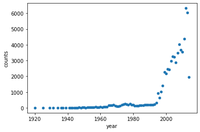

```python
# Number of reported sightings every year.

print(df.datetime.min())
print(df.datetime.max())

# Slicing the data to only include data after 1914 (since the last recorded entry is 2014, I think having an even
# 100 years will make for better grouping later on).
df_sum = df[df['datetime'] >= '1914-01-01']
df_sum['year'] = df['datetime'].dt.year

df_counts = df_sum.groupby(['year']).size().reset_index(name='counts')
ax_counts = df_counts.plot.scatter(x='year', y='counts', title='UFO Sightings Over Time')
```

Based on the scatterplot, we can see that in the mid-to-late 90's a spike in recorded UFO appearences was experienced in the U.S. Maybe it had something to do with the release of E.T. in 1982? Anyways, we'll investigate further and see if we can uncover anymore localized trends that occurred during this spike.

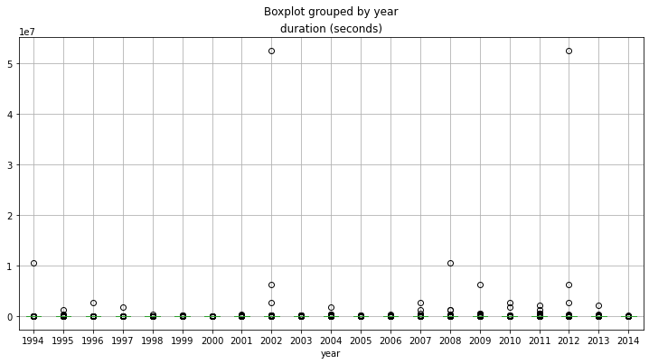

```python
# How did the durations of recorded UFO sightings change over 1994-2014? Let's see.
df_recent = df_sum[df_sum['datetime'] >= '1994-01-01']
boxplot = df_recent.boxplot(column=['duration (seconds)'], by='year', figsize=(12,6))

# We can't glean much from this box plot because of the few outliers in 2002 and 2012 that showed really long UFO sightings.
# We can try something else though... plenty of data to explore.
```

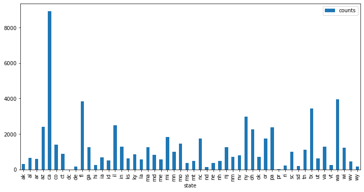

```python
# Which states have the most sightings?
df_states = df_sum.groupby(['state']).size().reset_index(name='counts')
ax_states = df_states.plot.bar(x='state', y='counts', figsize = (12,6))

# Notice I set the figsize to (12,6) for these graphs so we can read the labels along the x-axis.
# While we could map this data, the bar graph is a quick and easy way to see trends without having to manage the
# waiting time that comes with mapping large amounts of data (like these thousands of recordings... but we can
# certainly find smaller subsets of data to map and look at.)
```

```python
# Best places to go star searching in the DMV? Next time we have a long weekend at UMD... take a trip out to one of these locations.
df_md = df_sum[df_sum['state'] == 'md']
```

```python
# There are a total of 837 sightings in Maryland, which makes for a good number of locations to plot. Overall, this kind
# of data is perfect for a map because the sightings are location-oriented and you have different identifiers that could
# be used to differentiate points (like shape of the UFO and duration).

# To get our map started we need to first make sure that Folium will load its map looking at the area of interest,
# in this case, Maryland.
# For any location, you can Google the coordinates, and then play with the zoom_start until you feel like the entire
# area is in the lens of the map. From there, you can also toggle the coordinates a bit to maximize the space.

map_osm = folium.Map(location=[39.03, -76.94], zoom_start=7.5)

df_md['shape'].unique().tolist()
```

```
['sphere',
 'light',
 'rectangle',
 'triangle',
 'cigar',
 'oval',
 'flash',
 'circle',
 'disk',
 'chevron',
 'other',
 'diamond',
 'fireball',
 nan,
 'formation',
 'unknown',
 'cylinder',
 'changing',
 'teardrop',
 'egg']
```

```python
df_md.reset_index()

for i in range(0, len(df_md)):
    # Round shapes will be blue
    if df_md.iloc[i]['shape'] == ('sphere' or 'cylinder' or 'oval' or 'circle' or 'egg' or 'teardrop' or 'disk'):
        folium.Marker(
            location=[df_md.iloc[i]['latitude'], df_md.iloc[i]['longitude']],
            popup=df_md.iloc[i]['comments'],
        ).add_to(map_osm)

    # "Light" shapes will be green
    elif df_md.iloc[i]['shape'] == ('light' or 'flash'):
        folium.Marker(
            location = [df_md.iloc[i]['latitude'], df_md.iloc[i]['longitude']],
            popup=df_md.iloc[i]['comments'],
            icon = folium.Icon(color='green'),
            ).add_to(map_osm)

    # Rectangular shapes will be red
    elif df_md.iloc[i]['shape'] == ('rectangle' or 'diamond'):
        folium.Marker(
            location = [df_md.iloc[i]['latitude'], df_md.iloc[i]['longitude']],
            popup=df_md.iloc[i]['comments'],
            icon = folium.Icon(color='red'),
            ).add_to(map_osm)

    # Triangular shapes will be yellow
    elif df_md.iloc[i]['shape'] == ('triangle' or 'chevron'):
        folium.Marker(
            location = [df_md.iloc[i]['latitude'], df_md.iloc[i]['longitude']],
            popup=df_md.iloc[i]['comments'],
            icon = folium.Icon(color='yellow'),
            ).add_to(map_osm)
    else:
        folium.Marker(
            location = [df_md.iloc[i]['latitude'], df_md.iloc[i]['longitude']],
            popup=df_md.iloc[i]['comments'],
            icon = folium.Icon(color='brown'),
            ).add_to(map_osm)

map_osm
```

Make this Notebook Trusted to load map: File -> Trust Notebook

[interactive chart not shown]

The map gives us some pretty interesting insights. I would have imagined that most of the sightings would have been in Western Maryland where the area is more rural. Albeit with less people living there less people to report sightings. It seems the most common descriptors for sightings in Maryland have been some variation of 'round' or a 'flash of light,' which also makes sense considering UFOS far away probably can't give off very distinct shapes.